# Egzaminas

Edgaras Petrauskas

Tuesday, May 31, 2016

```r
library(car)
library(fpp)
library(dynlm)
library(knitr)
```

## 2.Užduotis

# 1.

**a)**

```r
data <- read.csv2("data_b.csv", header=TRUE)
attach(data)
str(data)
```

```
## 'data.frame':    352 obs. of  5 variables:
##  $ kaina      : Factor w/ 350 levels "10001.4","10008.5",..: 68 85 119 207 244 208 233 223 170 43 ...
##  $ rida       : Factor w/ 352 levels "1436010.97952486",..: 3 316 219 93 296 111 78 114 164 183 ...
##  $ amzius     : Factor w/ 18 levels ">20","10","11",..: 3 4 7 10 18 13 10 11 3 3 ...
##  $ galia      : int  55 55 75 65 55 65 65 45 55 65 ...
##  $ markesKodas: Factor w/ 3 levels "bm","ky","qt": 3 2 2 3 1 2 2 2 2 1 ...
```

```r
head(data)
```

```
##     kaina             rida  amzius galia markesKodas
## 1 13515.1 164110.850559981      11    55          qt
## 2 15340.6 673467.350444128      12    55          ky
## 3 17763.8 494773.347639264      15    75          ky
## 4 24493.5 360467.882751469       2    65          qt
## 5  5805.8 601594.656948206 MISSING    55          bm
## 6 24618.7 377599.274933091       5    65          ky
```

**b)**

```r
sum(data == "MISSING")
```

```
## [1] 5
```

Yra 5 reiksmes missing, kurias reikia pasalinti. Taip pat str parode, jog kaina, rida ir amzius traktuojami kaip faktoriai, nors is tikro jie turetu buti numeric tipo, todel reikia juos pakeisti i tinkama duomenu tipa.

```r
data <- data[-c(5, 54, 97, 100, 201), ]
str(data)
```

```
## 'data.frame':    347 obs. of  5 variables:
##  $ kaina      : Factor w/ 350 levels "10001.4","10008.5",..: 68 85 119 207 208 233 223 170 43 94 ...
##  $ rida       : Factor w/ 352 levels "1436010.97952486",..: 3 316 219 93 111 78 114 164 183 215 ...
##  $ amzius     : Factor w/ 18 levels ">20","10","11",..: 3 4 7 10 13 10 11 3 3 6 ...
##  $ galia      : int  55 55 75 65 65 65 45 55 65 75 ...
##  $ markesKodas: Factor w/ 3 levels "bm","ky","qt": 3 2 2 3 2 2 2 2 1 2 ...
```

Pasalinti 5 irasai, liko 347 irasai

```r
suppressWarnings(as.numeric(levels(kaina))[kaina])
```

[output not shown]

[output cut: 29 more lines]

```r
as.numeric(levels(rida))[rida]
```

[output not shown]

[output cut: 36 more lines]

```r
suppressWarnings(as.numeric(levels(amzius))[amzius])
```

[output not shown]

## 3.Užduotis

Duomenu vizulizacija

```r
head(M1Germany)
```

```
##            logm1 logprice   loggnp interest
## 1960 Q1 7.947090 3.403827 8.309448    0.062
## 1960 Q2 7.996191 3.380212 8.387236    0.064
## 1960 Q3 7.949908 3.436211 8.465361    0.064
## 1960 Q4 8.030746 3.419888 8.477333    0.062
## 1961 Q1 7.951792 3.449861 8.374404    0.060
## 1961 Q2 8.020040 3.427157 8.420854    0.057
```

```r
str(M1Germany)
```

```
## 'zooreg' series from 1960 Q1 to 1996 Q3
##   Data: num [1:147, 1:4] 7.95 8 7.95 8.03 7.95 ...
##  - attr(*, "dimnames")=List of 2
##   ..$ : chr [1:147] "1" "2" "3" "4" ...
##   ..$ : chr [1:4] "logm1" "logprice" "loggnp" "interest"
##   Index: Class 'yearqtr'  num [1:147] 1960 1960 1960 1961 1961 ...
##   Frequency: 4
```

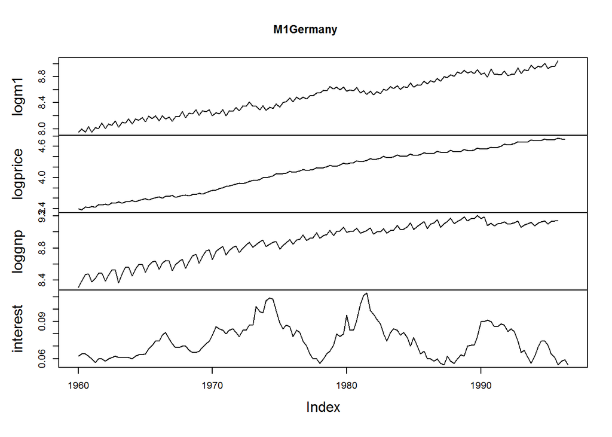

```r
plot(M1Germany)
```

**a)** Įvertinkite tiesinę regresija žemiau pateikto modelio:

```r
mod1 <- dynlm(logm1 ~ L(logprice,1), data = M1Germany)
kable(summary(mod1)$coef,digits=2)
```

|  | Estimate | Std. Error | t value | Pr(>\|t\|) |
| --- | --- | --- | --- | --- |
| (Intercept) | 5.62 | 0.05 | 113.57 | 0 |
| L(logprice, 1) | 0.70 | 0.01 | 58.36 | 0 |

**b)** Liekanos transformuojamos i laiko eilute:

```r
serOrg <- mod1$res
liekanu_ts <- ts(serOrg, start=1960, frequency=4)
str(liekanu_ts)
```

```
##  Time-Series [1:143] from 1960 to 1996: -0.00332 -0.0331 0.00862 -0.05893 -0.01162 ...
##  - attr(*, "index")=Class 'yearqtr'  num [1:143] 1960 1960 1961 1961 1961 ...
##  - attr(*, "frequency")= num 4
```

**c)** Isbreziama serOrg ir pastebimas sezoniskumas:

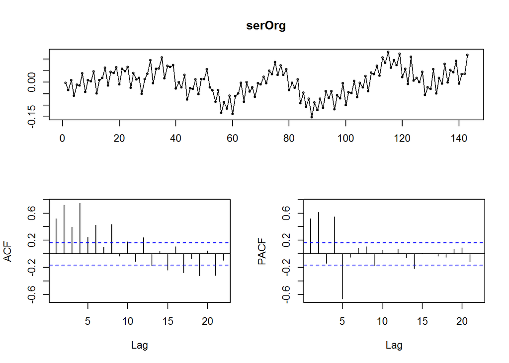

```r
tsdisplay(serOrg)
```

Bandysime pasalinti sezoniskuma.

Pirmasis budas:

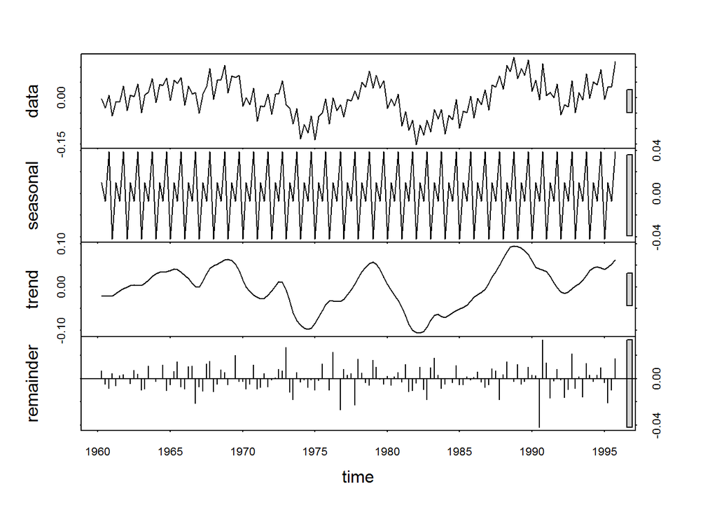

```r
naikinam <- stl(serOrg, s.window="periodic")
plot(naikinam)
```

```r
# Pavaizduojami eiliskumo tvarka: originalus duomenys, sezonine komponente, trendo komponente ir likutis
```

```r
head(naikinam$time.series)
```

```
##          seasonal        trend    remainder
## [1,]  0.010124789 -0.020255369  0.006814929
## [2,] -0.007101511 -0.021221856 -0.004779640
## [3,]  0.038787381 -0.021741077 -0.008426695
## [4,] -0.041810653 -0.021490459  0.004367376
## [5,]  0.010124789 -0.015418728 -0.006327980
## [6,] -0.007101511 -0.009326109  0.002705463
```

```r
head(naikinam$time.series[,1])
```

```
## [1]  0.010124789 -0.007101511  0.038787381 -0.041810653  0.010124789
## [6] -0.007101511
```

```r
reikalinga <- naikinam$time.series[,1]
str(naikinam)
```

```
## List of 8
##  $ time.series: mts [1:143, 1:3] 0.0101 -0.0071 0.0388 -0.0418 0.0101 ...
##   ..- attr(*, "dimnames")=List of 2
##   .. ..$ : NULL
##   .. ..$ : chr [1:3] "seasonal" "trend" "remainder"
##   ..- attr(*, "tsp")= num [1:3] 1960 1996 4
##   ..- attr(*, "class")= chr [1:3] "mts" "ts" "matrix"
##  $ weights    : num [1:143] 1 1 1 1 1 1 1 1 1 1 ...
##  $ call       : language stl(x = serOrg, s.window = "periodic")
##  $ win        : Named num [1:3] 1431 7 5
##   ..- attr(*, "names")= chr [1:3] "s" "t" "l"
##  $ deg        : Named int [1:3] 0 1 1
##   ..- attr(*, "names")= chr [1:3] "s" "t" "l"
##  $ jump       : Named num [1:3] 144 1 1
##   ..- attr(*, "names")= chr [1:3] "s" "t" "l"
##  $ inner      : int 2
##  $ outer      : int 0
##  - attr(*, "class")= chr "stl"
```

```r
reikalinga_ts <- ts(reikalinga, start=1960, frequency=4)
head(liekanu_ts)
```

```
## [1] -0.003315651 -0.033103007  0.008619609 -0.058933736 -0.011621919
## [6] -0.013722157
```

```r
head(reikalinga_ts)
```

```
## [1]  0.010124789 -0.007101511  0.038787381 -0.041810653  0.010124789
## [6] -0.007101511
```

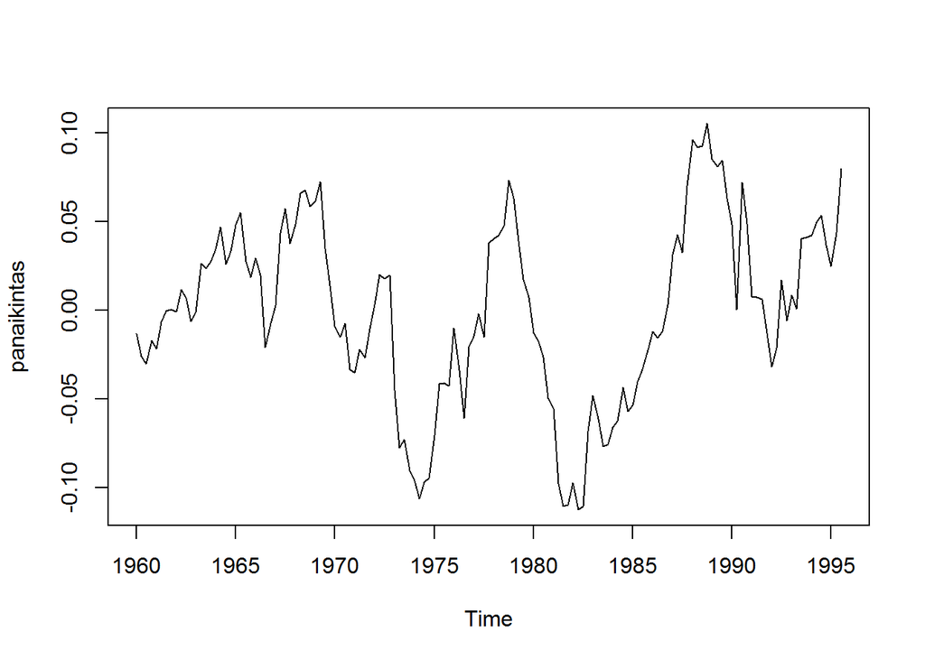

```r
panaikintas <- liekanu_ts-reikalinga_ts
plot(panaikintas)
```

Antrasis budas:

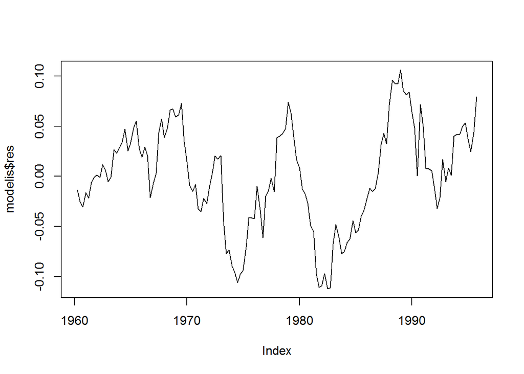

```r
modelis <- lm(serOrg ~ reikalinga, data=M1Germany)
plot(modelis$res)
```

Abieju budu rezultatai vienodi, pirmenybe teiksiu pirmam budui. Nusezoninta eilute priskirsiu ser.

```r
ser <- panaikintas
str(ser)
```

```
##  Time-Series [1:143] from 1960 to 1996: -0.0134 -0.026 -0.0302 -0.0171 -0.0217 ...
```

**d)** Tikriname, ar ser eilute stacionari.

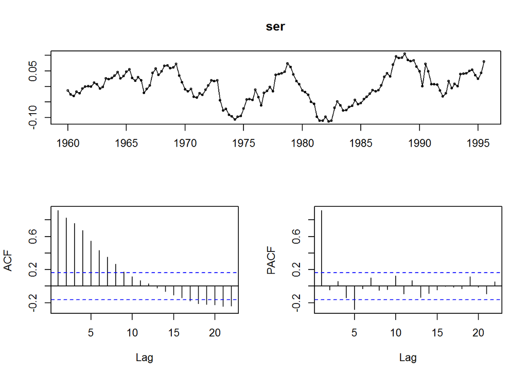

```r
tsdisplay(ser)
```

```r
n <- ndiffs(ser) # surandama diferencijavimo eilė
n
```

```
## [1] 0
```

**e)**

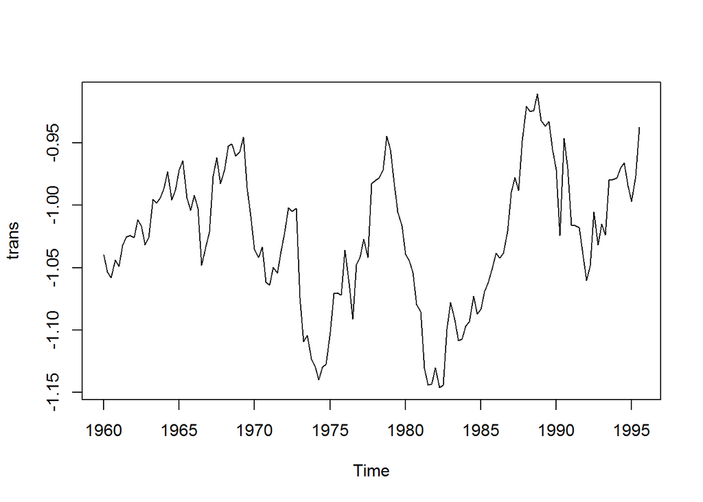

```r
lambda <- BoxCox.lambda(ser) # lambdos radimas
trans <- BoxCox(ser, lambda) # įvykdoma Box-Cox transformacija
plot(trans)
```

Variacija nesikeicia, todel Box-Cox transformacija nebutina.